# Skills for Analysis Assignment 2

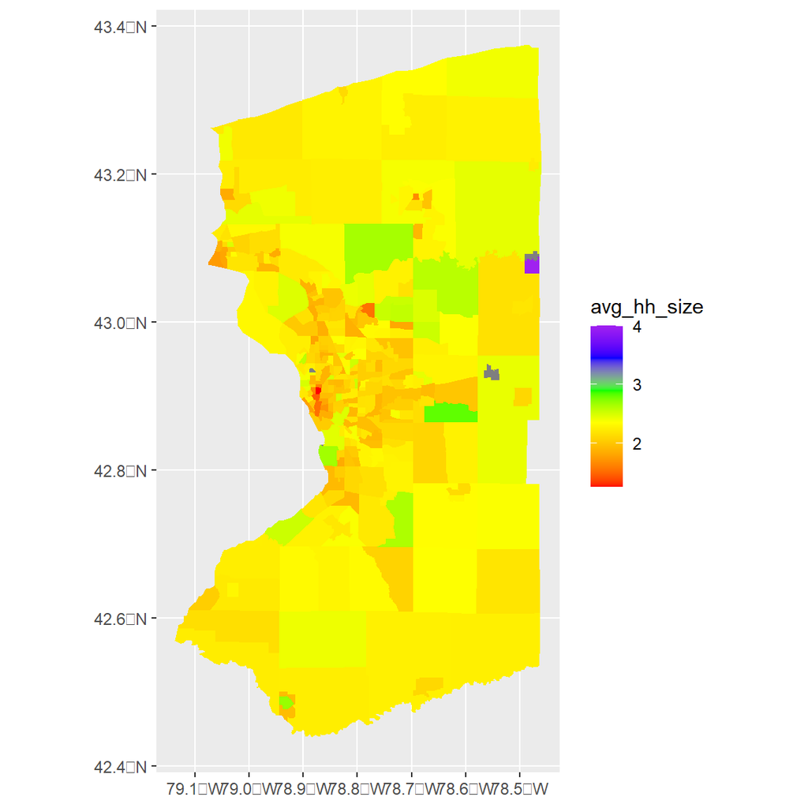

```r
hh_size_map +
  scale_fill_gradientn(colors = c("red",
                                  "orange",
                                  "yellow",
                                  "green",
                                  "blue",
                                  "purple"))
```

The `RColorBrewer` package offers a bunch of pre-defined palettes that can be useful for continuous data. You can view the options with the function `display.brewer.all()

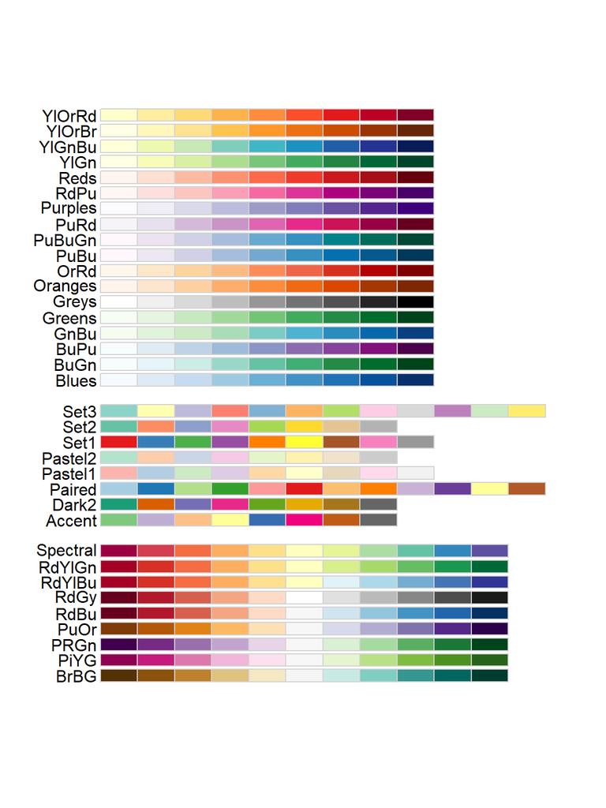

```r
library(RColorBrewer)

display.brewer.all()
```

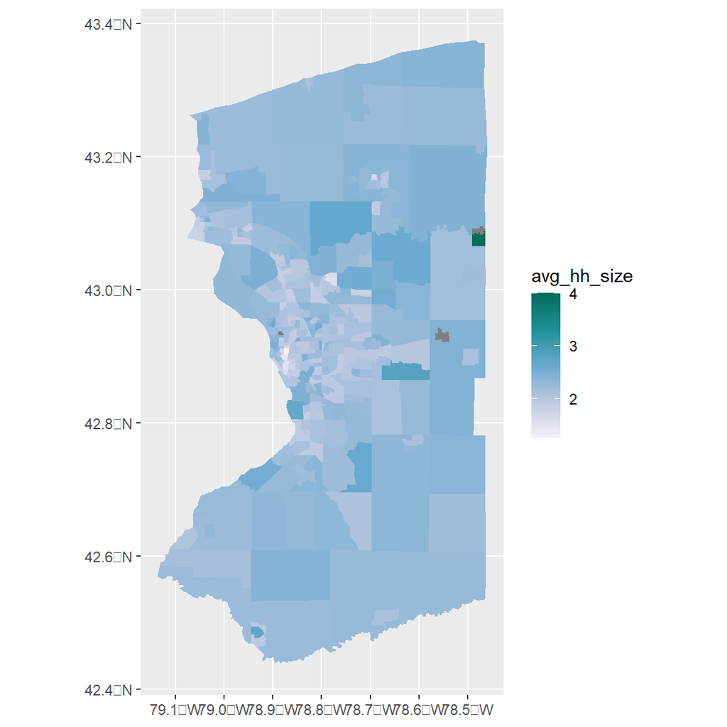

```r
map_palette <- brewer.pal(5, "PuBuGn")

hh_size_map +
  scale_fill_gradientn(colors = map_palette)
```

The last group of colors are diverging palettes, which range from dark to light to dark colors.

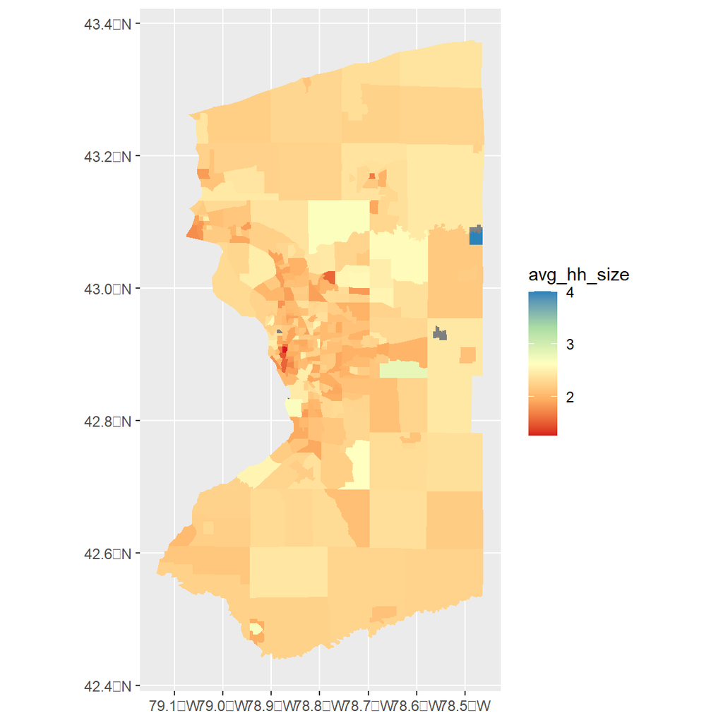

```r
map_palette <- brewer.pal(5, "Spectral")

hh_size_map +
  scale_fill_gradientn(colors = map_palette)
```

The middle group are qualitative palettes which work well for categorical variables, but would be confusing for a continuous color ramp.

There are some other fun package that define color palettes, including wesanderson (colors inspired by Wes Anderson films), [PNWColors](https://jakelawlor.github.io/portfolio/pnwcolors/) (colors inspired by the package author’s photos of the Pacific Northwest), [MetBrewer](https://github.com/BlakeRMills/MetBrewer/tree/main) (inspired by works at the Metropolitan Museum of Art), and [MexBrewer](https://paezha.github.io/MexBrewer/) (inspired by works of Mexican muralists). These four packages are structured similarly. Some of the available palettes don’t work well for continuous variables (the order of the colors isn’t intuitive), but some work well.

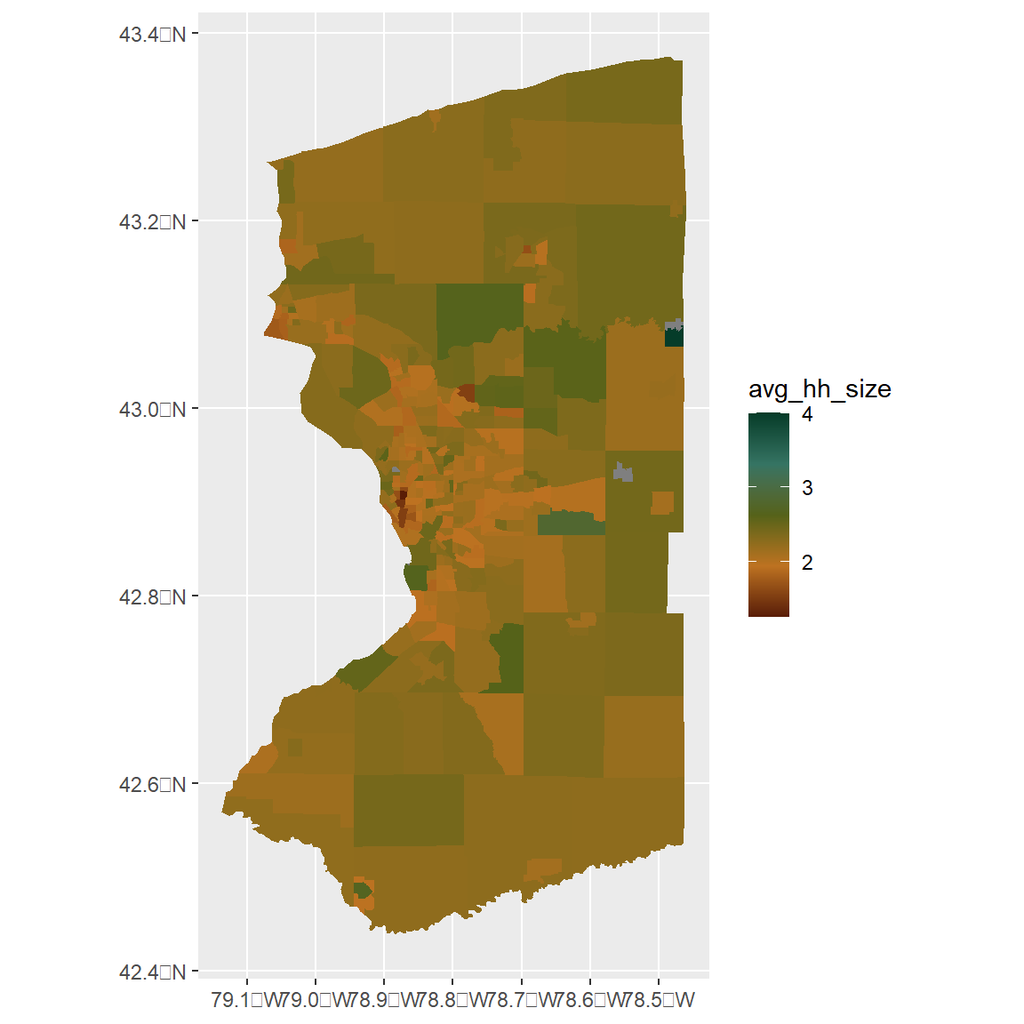

```r
library(MetBrewer)

degas_contin <- met.brewer(name = "Degas", n = 5, type = "continuous")

hh_size_map +
  scale_fill_gradientn(colors = degas_contin)
```

# Define study area boundary

In this class, your study area is a metropolitan statistical area. You can use the `tigris` or `tidycensus` package to get the boundary of your study area. This can be especially useful if your study area includes many counties.

If all you need is the boundary, you can use the `core_based_statistical_areas()` function in the `tigris` package. That will return the boundaries for all the CBSAs in the United States. Then you can filter those to only keep the one corresponding to your study area (I’m using Buffalo in this example - the GEOID is 15380)

```r
library(tidyverse)
library(tigris)

boundary <- core_based_statistical_areas() %>%
  filter(GEOID == "15380")
```

If you also want to get region-level data in addition to just the boundaries, you can use the tidycensus package (see the “Get Regional Data” topic).

# Download census tract data

You’ll need to download several tract-level variables from the census. You’ll find the `tidycensus` package super useful for this.

Assuming you’ve already [defined a list of variables](https://gsd-ses-5394-s2022.github.io/Richmond/a2_skills.html#list-census-variable-names) and saved it as a [character vector](https://r4ds.had.co.nz/vectors.html) called `vars`, you can use the `get_acs()` function in the `tidycensus` package to download the data.

```r
vars <- c(total_hhs = 'B08203_001',
          no_veh = 'B08203_002',
          hh_1person = 'B08201_007',
          hh_2person = 'B08201_013',
          hh_3person = 'B08201_019',
          hh_4person_plus = 'B08201_025',
          inc_lt_10k = 'B19001_002',
          inc_btw_10k_15k = 'B19001_003',
          inc_btw_15k_20k = 'B19001_004',
          inc_btw_20k_25k = 'B19001_005',
          inc_btw_25k_30k = 'B19001_006',
          inc_btw_30k_35k = 'B19001_007',
          inc_btw_35k_40k = 'B19001_008',
          inc_btw_40k_45k = 'B19001_009',
          inc_btw_45k_50k = 'B19001_010',
          inc_btw_50k_60k = 'B19001_011',
          inc_btw_60k_75k = 'B19001_012',
          inc_btw_75k_100k = 'B19001_013',
          inc_btw_100k_125k = 'B19001_014',
          inc_btw_125k_150k = 'B19001_015',
          inc_btw_150k_200k = 'B19001_016',
          inc_gt_200k = 'B19001_017')
```

I’ll use the `get_acs()` function from the `tidycensus` package. `geography = 'tract'` means I want tract-level data. I’ll also specify the state and county (or counties - I can provide a list of all the counties in my study area here if there is more than one). In most cases, I’ll set `output = wide` because I want each variable in its own column (you can see an exception here though). You’ll also need the zone/tract boundaries at some point, so you should get those at the same time by setting `geometry = TRUE`.

```r
library(tidycensus)

census <- get_acs(geography = 'tract',
                 state = 'NY',
                 county = c('Erie', 'Niagara'),
                 variables = vars,
                 output = 'wide',
                 geometry = TRUE)
```

If your study area has a lot of counties, you might find it really tiresome to type in the names of all of them. Another approach is to define the study area boundary (see the “Define study area boundary” topic - in this example, I’ve saved it to an layer called `boundary`), then download census tracts for the entire state (i.e. leave the county argument out), and then filter them to only include the ones within the study area. This will not work if you do not set `geometry = TRUE` in the `get_acs()` function.

In order to avoid capturing that are adjacent to my study area, I’m going to select based on centroid locations.

```r
library(tidycensus)
library(sf)

va_census <- get_acs(geography = 'tract',
                 state = 'VA',
                 variables = vars,
                 output = 'wide',
                 geometry = TRUE)

census_centroids <- st_centroid(va_census) %>%
  st_filter(boundary)

census <- va_census %>%
  st_filter(census_centroids)
```

# Download employment data

The Longitudinal Employer-Household Dynamica (LEHD) dataset is a great source of census-block level employment data by industry.

Select the appropriate state from the drop-down menu, and select ‘Workplace Area Characteristics (WAC)’ from the ‘Type’ drop-down menu. Then click the ‘View Files’ button to see a list of available files. You can read about the file naming conventions [here](https://lehd.ces.census.gov/data/lodes/LODES7/LODESTechDoc7.5.pdf). The one you want is called [xx]_wac_S000_JT00_2019.csv.gz, where xx is the two-letter postal code for the state. Right-click on the link for the file and select ‘copy link address’.

You can read in the file to R directly from that link. That file has 53 variables in it. The ones you want give the number of workers by industry code. See page 7 of [this document](https://lehd.ces.census.gov/data/lodes/LODES7/LODESTechDoc7.5.pdf). You’ll want:

So you can use `select()` to keep those (and use `mutate()` to calculate service employment) and drop everything else (make sure you also keep w_geocode, which has the GEOID for the block).

This data is at the census block level, not the tract level. You’ll need to collapse it to the tract level (see the “Collapse data” topic).

```r
library(tidyverse)

lehd_blocks <- read_csv('https://lehd.ces.census.gov/data/lodes/LODES7/ny/wac/ny_wac_S000_JT00_2019.csv.gz', show_col_types = FALSE) %>%
  rename(total_emp = C000) %>%
  mutate(basic_emp = CNS01+CNS02+CNS03+CNS04+CNS05+CNS06+CNS08+CNS09) %>%
  rename(retail_emp = CNS07) %>%
  mutate(service_emp = total_emp - basic_emp - retail_emp) %>%
  select(w_geocode, total_emp, basic_emp, retail_emp, service_emp)
```

# Find census variables

You’ll need to search for the names of the variables you want to include in your analysis.

If you’ve already loaded the `tidycensus` package, you can type `View(load_variables(2019, "acs5"))`* into your console to interactively search for variables that you’d like to include in your analysis. That will open a table of all the available variables in your viewer. Here’s what you’ll see if you start searching for variables that have to do with vehicles:

[figure not shown]

You’ll see that the table has three columns.

- The first column is the variable name. The variable name will have two parts: the part before the underscore tells you which table the variable is a part of, that the part after the underscore tells you which row the variable is in.
- The second column is the variable label. This describes that specific variable.
- The third column, called “concept,” is the name of the table identified in the first part of the variable name.

Many tables are cross-tabulations that present the number of people, homes, or households in each combination of two categories. Many values can be found in multiple tables. For example, you can find the total number of workers who commute to work by car in B08006 (Sex of worker by means of transportation to work) and B08101 (Means of transportation to work by age).

* *The first argument (`2019`) indicates that you want the variables that are available for 2019 and the second argument (`"acs5"`) indicates that you want variables that are included in the 5-year sample of the American Community Survey. The 5-year sample is from survey respondents pooled over a 5-year period. An alternative is `"acs1"`, which would give you just the households who completed the survey in 2019 (which is a much smaller sample, so those estimates would have more uncertainty associated with them). You could also specify `"sf1"` instead of `"acs5"` or `"acs1"` if you wanted data from the decennial census. The decennial census is meant to include everyone, so there is no sampling error, but fewer variables are available.*

# Get regional data

Your analysis will be at the tract level, but you might want to calculate some regional-level statistics as well - either because you want to just give a description of the region as a whole in your report or because you want to calculate a variable that reports tract-level statistics to regional statistics (e.g. income relative to the regional median).

The example here incorporates some of the skills covered in other sections.

In this example, I want to have some tract-level variables that indicate how many households are in each income quintile, so I’ll calculate the regional 20th, 40th, 60th, and 80th percentiles to use as thresholds.

```r
vars <- c(inc_lt_10k = 'B19001_002',
          inc_btw_10k_15k = 'B19001_003',
          inc_btw_15k_20k = 'B19001_004',
          inc_btw_20k_25k = 'B19001_005',
          inc_btw_25k_30k = 'B19001_006',
          inc_btw_30k_35k = 'B19001_007',
          inc_btw_35k_40k = 'B19001_008',
          inc_btw_40k_45k = 'B19001_008',
          inc_btw_45k_50k = 'B19001_010',
          inc_btw_50k_60k = 'B19001_011',
          inc_btw_60k_75k = 'B19001_012',
          inc_btw_75k_100k = 'B19001_013',
          inc_btw_100k_125k = 'B19001_014',
          inc_btw_125k_150k = 'B19001_015',
          inc_btw_150k_200k = 'B19001_016',
          inc_gt_200k = 'B19001_017')
```

Then I’ll download those variables (see the “Download Census tract data” topic) for all the core-based statistical areas in United States (`geography = metropolitan statistical area/micropolitan statistical area"` instead of `geography = "tract"`). I am *not* setting `output = 'wide'` because in this case I actually *do* want each variable in its own row (there will be a column with the variable name and column called `estimate` with the value of each variable). I’m setting `summary_var = 'B19001_001'` because that’s the total number of households, and I want to calculate what percent of total households fall in each category.

If you need the spatial extent of the study area, you could just add `geometry = TRUE` to the `get_acs()` function instead of [getting the boundaries through the `tigris` package] (see the “Define study area boundary” topic for how to get the boundary from the Tigris package). I’m setting `geometry = FALSE` in this case, assuming I don’t need the study area boundary data.

After a pipe (`%>%`) I filter the data to only include my study area (I’m using Buffalo in this example - the GEOID is 15380).

After another pipe, I create a variable (see the “Calculate new variables” topic) with the percent of households in each category, and then I use the `cumsum()` function to calculate a cumulative percentage. Finally, I delete the columns I don’t need (see the “Organize data columns” topic), keeping only the cumulative percentage and variable names.

```r
library(tidycensus)
library(tidyverse)
library(knitr)

region_inc <- get_acs(
  geography = "cbsa",
  variables = vars,
  summary_var = 'B19001_001',
  geometry = FALSE) %>%
  filter(GEOID == "15380") %>%
  mutate(pct = estimate / summary_est) %>%
  mutate(cumul_pct = cumsum(pct)) %>%
  select(variable, cumul_pct)
```

Now I can print the table (see the “Summarize tract statistics” topic).

```r
kable(region_inc, digits=2)
```

| variable | cumul_pct |
| --- | --- |
| inc_lt_10k | 0.06 |
| inc_btw_10k_15k | 0.11 |
| inc_btw_15k_20k | 0.15 |
| inc_btw_20k_25k | 0.20 |
| inc_btw_25k_30k | 0.24 |
| inc_btw_30k_35k | 0.29 |
| inc_btw_35k_40k | 0.33 |
| inc_btw_45k_50k | 0.36 |
| inc_btw_50k_60k | 0.44 |
| inc_btw_60k_75k | 0.54 |
| inc_btw_75k_100k | 0.67 |
| inc_btw_100k_125k | 0.76 |
| inc_btw_125k_150k | 0.82 |
| inc_btw_150k_200k | 0.89 |
| inc_gt_200k | 0.96 |

From the table above, I can see that 20 percent of households have incomes below $25,000 per year, 36 percent have incomes below $50,000 per year, 54 percent have incomes below $75,000, and 82 percent have incomes below $150,000 per year. These are thresholds I could use to define broader income categories (which approximately correspond to quintiles) for my tract-level data.

# Join two data frames

If you have employment data in one dataframe (see the “Download employment data” topic) and population data in another (see the “Download census tract data” topic), you’ll want to combine them into a single dataframe.

In these examples, I know my population data only includes tracts in my study area because I filtered to to my study area boundary. My employment data is for the whole state. I’ll do a left join, with the population data on the left (i.e. listed first), which wil drop all the rows of the employment data that aren’t include in my population data.

```r
zones <- left_join(census, lehd_tracts)
```

A quick review on what the pipe (`%>%`) does. It takes the output of the function before it and enters it as the first argument in the function after it. So the line in the chunk above this is exactly the same as the following lines with a pipe:

```r
zones <- census %>%
  left_join(lehd_tracts)
```

# List census variable names

Once you’ve identified the census variable you want to include in your analysis (see the “Find census variables” topic), you can create a list of them. The function `c()` lets you list a bunch of items so you can pass them into another function (for example, the `get_acs()` function - see the “Download census tract data” topic) as a single argument. You could just list all the variable names you’ve identified like this:

```r
vars <- c('B08203_001',
          'B08203_002',
          'B08201_007',
          'B08201_013',
          'B08201_019',
          'B08201_025',
          'B19001_002',
          'B19001_003',
          'B19001_004',
          'B19001_005',
          'B19001_006',
          'B19001_007',
          'B19001_008',
          'B19001_009',
          'B19001_010',
          'B19001_011',
          'B19001_012',
          'B19001_013',
          'B19001_014',
          'B19001_015',
          'B19001_016',
          'B19001_017')
```

But remember that you don’t only want computers to be able to read your code. You want humans (including your future self) to be able to read it too. To that end, you can also define more intelligible variable names when you list your variables.

```r
vars <- c(total_hhs = 'B08203_001',
          no_veh = 'B08203_002',
          hh_1person = 'B08201_007',
          hh_2person = 'B08201_013',
          hh_3person = 'B08201_019',
          hh_4person_plus = 'B08201_025',
          inc_lt_10k = 'B19001_002',
          inc_btw_10k_15k = 'B19001_003',
          inc_btw_15k_20k = 'B19001_004',
          inc_btw_20k_25k = 'B19001_005',
          inc_btw_25k_30k = 'B19001_006',
          inc_btw_30k_35k = 'B19001_007',
          inc_btw_35k_40k = 'B19001_008',
          inc_btw_40k_45k = 'B19001_009',
          inc_btw_45k_50k = 'B19001_010',
          inc_btw_50k_60k = 'B19001_011',
          inc_btw_60k_75k = 'B19001_012',
          inc_btw_75k_100k = 'B19001_013',
          inc_btw_100k_125k = 'B19001_014',
          inc_btw_125k_150k = 'B19001_015',
          inc_btw_150k_200k = 'B19001_016',
          inc_gt_200k = 'B19001_017')
```

# Organize data columns

At some point, you’ll find you have more columns in your dataframe that you need. You can use the `select()` function to delete variables you don’t need and also to reorder columns.

Here are the first few rows of a dataframe with a 59 columns:

```r
library(knitr)
library(kableExtra)

kable(head(zones)) %>%
  scroll_box(width = "100%", height = "500px")
```

| GEOID | NAME | total_hhsE | total_hhsM | no_vehE | no_vehM | hh_1personE | hh_1personM | hh_2personE | hh_2personM | hh_3personE | hh_3personM | hh_4person_plusE | hh_4person_plusM | inc_lt_10kE | inc_lt_10kM | inc_btw_10k_15kE | inc_btw_10k_15kM | inc_btw_15k_20kE | inc_btw_15k_20kM | inc_btw_20k_25kE | inc_btw_20k_25kM | inc_btw_25k_30kE | inc_btw_25k_30kM | inc_btw_30k_35kE | inc_btw_30k_35kM | inc_btw_35k_40kE | inc_btw_35k_40kM | inc_btw_40k_45kE | inc_btw_40k_45kM | … |
| --- | --- | --- | --- | --- | --- | --- | --- | --- | --- | --- | --- | --- | --- | --- | --- | --- | --- | --- | --- | --- | --- | --- | --- | --- | --- | --- | --- | --- | --- | --- |
| 36029009402 | Census Tract 94.02, Erie County, New York | 1952 | 145 | 66 | 47 | 619 | 91 | 677 | 136 | 287 | 102 | 369 | 89 | 35 | 29 | 61 | 49 | 25 | 23 | 41 | 32 | 21 | 24 | 30 | 26 | 66 | 55 | 94 | 61 | … |
| 36029011400 | Census Tract 114, Erie County, New York | 1089 | 192 | 245 | 102 | 293 | 111 | 465 | 182 | 109 | 48 | 222 | 75 | 85 | 52 | 105 | 71 | 45 | 51 | 44 | 43 | 23 | 19 | 81 | 54 | 53 | 42 | 53 | 39 | … |
| 36029015002 | Census Tract 150.02, Erie County, New York | 1285 | 109 | 45 | 37 | 354 | 116 | 492 | 131 | 220 | 103 | 219 | 64 | 44 | 42 | 8 | 14 | 5 | 10 | 60 | 38 | 24 | 23 | 26 | 30 | 43 | 43 | 41 | 26 | … |
| 36063022100 | Census Tract 221, Niagara County, New York | 973 | 95 | 70 | 45 | 385 | 89 | 255 | 85 | 179 | 83 | 154 | 52 | 56 | 39 | 56 | 37 | 28 | 33 | 52 | 43 | 51 | 39 | 65 | 48 | 38 | 33 | 62 | 53 | … |
| 36063022715 | Census Tract 227.15, Niagara County, New York | 803 | 198 | 0 | 13 | 86 | 92 | 394 | 108 | 2 | 28 | 321 | 217 | 0 | 13 | 0 | 13 | 18 | 29 | 0 | 13 | 24 | 45 | 0 | 13 | 77 | 88 | 42 | 40 | … |
| 36029013002 | Census Tract 130.02, Erie County, New York | 2503 | 212 | 177 | 98 | 880 | 154 | 1007 | 193 | 307 | 143 | 309 | 127 | 16 | 24 | 127 | 73 | 103 | 75 | 264 | 149 | 133 | 85 | 163 | 102 | 146 | 92 | 80 | 53 | … |

- `GEOID`
- `total_hhsE`
- `no_vehE`
- `hh_1personE`
- `hh_2personE`
- `hh_3personE`
- `hh_4person_plusE`
- `inc_quint_1`
- `inc_quint_2`
- `inc_quint_3`
- `inc_quint_4`
- `inc_quint_5`
- `total_emp`
- `basic_emp`
- `retail_emp`
- `service_emp`

That’s the order they currently appear in, but for whatever reason, I’d like the employment variables to come first.

```r
library(knitr)
library(kableExtra)
library(tidyverse)

final_data <- zones %>%
  select(GEOID,
         total_emp,
         basic_emp,
         retail_emp,
         service_emp,
         total_hhsE,
         no_vehE,
         hh_1personE,
         hh_2personE,
         hh_3personE,
         hh_4person_plusE,
         inc_quint_1,
         inc_quint_2,
         inc_quint_3,
         inc_quint_4,
         inc_quint_5)
```

```r
kable(head(final_data)) %>%
  scroll_box(width = "100%", height = "500px")
```

| GEOID | total_emp | basic_emp | retail_emp | service_emp | total_hhsE | no_vehE | hh_1personE | hh_2personE | hh_3personE | hh_4person_plusE | inc_quint_1 | inc_quint_2 | inc_quint_3 | inc_quint_4 | inc_quint_5 | geometry | hbo_prod | hbo_attr | hbo_attr_bal |
| --- | --- | --- | --- | --- | --- | --- | --- | --- | --- | --- | --- | --- | --- | --- | --- | --- | --- | --- | --- |
| 36029014604 | 1685 | 248 | 95 | 1342 | 3050 | 225 | 750 | 921 | 541 | 838 | 192 | 428 | 372 | 368 | 1690 | list(list(c(-78.69695, -78.696937, -78.696936, -78.696922, -78.696946, -78.696918, -78.687294, -78.684059, -78.65264, -78.652665, -78.652402, -78.652351, -78.652341, -78.64712, -78.647143, -78.667061,… | 14035.415 | 7803.6 | 6831.9932 |
| 36029016700 | 3352 | 2502 | 69 | 781 | 1090 | 279 | 509 | 289 | 174 | 118 | 362 | 326 | 188 | 107 | 107 | list(list(c(-78.814359, -78.814108, -78.814039, -78.814177, -78.807592, -78.80384, -78.800709, -78.799549, -78.799757, -78.799904, -78.804151, -78.804918, -78.808645, -78.809594, -78.81998, -78.814359… | 3995.051 | 5827.5 | 5101.9325 |
| 36029006901 | 338 | 7 | 10 | 321 | 1458 | 497 | 477 | 275 | 306 | 400 | 583 | 490 | 225 | 44 | 116 | list(list(c(-78.898233, -78.896256, -78.893526, -78.892701, -78.891591, -78.888792, -78.886155, -78.885442, -78.886, -78.887126, -78.888232, -78.88936, -78.890471, -78.892722, -78.894207, -78.895685, … | 6495.808 | 2233.0 | 1954.9747 |
| 36029009402 | 3411 | 37 | 268 | 3106 | 1974 | 54 | 667 | 610 | 325 | 372 | 252 | 236 | 317 | 207 | 962 | list(list(c(-78.783916, -78.783875, -78.782223, -78.779461, -78.778179, -78.773076, -78.767869, -78.764516, -78.764375, -78.761925, -78.759231, -78.75638, -78.755498, -78.760899, -78.764207, -78.76637… | 8212.962 | 14529.9 | 12720.8184 |
| 36063021300 | 105 | 11 | 31 | 63 | 884 | 218 | 386 | 216 | 114 | 168 | 480 | 233 | 95 | 68 | 8 | list(list(c(-79.041498, -79.038969, -79.033593, -79.033194, -79.033144, -79.033111, -79.0331, -79.038925, -79.041356, -79.041412, -79.041498, 43.095057, 43.09509, 43.09511, 43.095112, 43.09348, 43.091… | 3479.228 | 1107.4 | 969.5204 |
| 36029012901 | 3904 | 321 | 1827 | 1756 | 3273 | 213 | 953 | 1548 | 230 | 542 | 702 | 869 | 693 | 444 | 565 | list(list(c(-78.823852, -78.822948, -78.822955, -78.822998, -78.821937, -78.820864, -78.82303, -78.822942, -78.811704, -78.811416, -78.810467, -78.803819, -78.79726, -78.794891, -78.794882, -78.794075… | 13508.008 | 24008.6 | 21019.3491 |

# Separate geometry from dataset

You might have situations where you only need the zone boundaries, or you only need the zone data without the boundaries. You can separate them out before you save them.

If you just need the zone boundaries without any of the associated variables, you can use `select()` to drop everything except the geometry column and the GEOID (you still want the GEOID so you can identify the tract later).

```r
zone_boundaries <- final_data %>%
  select(GEOID, geometry)
```

If you just want the data without the geometry, you can use `st_drop_geometry()`.

```r
zone_data <- final_data %>%
  st_drop_geometry()
```

# Summarize tract statistics

```r
mean(census$avg_hh_size, na.rm = TRUE)
```

```
## [1] NA
```

```r
sd(census$avg_hh_size, na.rm = TRUE)
```

```
## [1] NA
```

You can also use summary() to get a quick set of summary statistics.

```r
summary(census$avg_hh_size)
```

```
## Length  Class   Mode
##      0   NULL   NULL
```

You can also use the `summarize()` function to create a quick table of summary statistics for a couple of variables. This isn’t the only possible way to do this.

First, I’ll use pivot_longer to get the variables I want into separate rows, then I’ll group by variable name and use summarize to calculate summary statistics.

```r
zone_data %>%
  pivot_longer(cols=c(total_emp, total_hhsE),
               names_to = "Variable",
               values_to = "value") %>%
  group_by(Variable) %>%
  summarize(Average = mean(value, na.rm=TRUE),
            `Standard deviation` = sd(value, na.rm=TRUE),
            Median = median(value, median(value, na.rm=TRUE)))
```

```
## # A tibble: 2 × 4
##   Variable   Average `Standard deviation` Median
##   <chr>        <dbl>                <dbl>  <dbl>
## 1 total_emp    1911.                3254.   1061
## 2 total_hhsE   1599.                 715.   1496
```

# Write data to a file

When you have all the zone data how you want it, you should save it to a file so you can use it for subsequent assignments. I recommend saving the tract boundaries and the data [separately](https://gsd-ses-5394-s2022.github.io/Richmond/a2_skills.html#separate-geometry-from-dataset), since the boundaries are the same for all alternatives, but population/employment data might be different, depending on whether your alternative includes land use changes in addition to (or rather than) transportation network changes.

To write spatial data, I suggest saving it to a geojson file using `st_write()`. st_write() can write spatial data to few different file formats, including ESRI shapefiles (useful if you want to bring your data into ArcGIS). I personally like the geojson format because I find it easy to work with.

```r
st_write(zone_boundaries, "zones/boundaries.geojson", append = FALSE)
```

To write tabular data, it makes sense to save it to a csv file using `write_csv()`.

```r
write_csv(final_data, "existing/data/zone_data.csv", append = FALSE)

write_csv(zones_new, "alternative/data/zone_data.csv", append = FALSE)
```

# Write figures to a file

Creating maps and charts in RMarkdown is great, but you’ll eventually want to save them as files you can include in a report or presentation. ggsave() will save the most recent plot to a filename you specify. That means you can call ggsave() immediately after plotting. You can specify the size of the image in inches (`units = "in"`), centimeters (`units = "cm"`), milimeters (`units = "mm"`), or pixels (`units = "px"`). You can also set the image resolution using the dpi argument, which can be a number (the number of dots per square inch) or one of three strings: `"retina"` (320 dpi), `"print"` (300 dpi - this the default), or `"screen"` (72 dpi). ggsave() can save to most common image file types. There is no need to specify a resolution if you want it to be 300 dpi (because that’s the default) or if you’re saving to a vector file type (pdf or svg, for example).

```r
hh_size_map
```

```r
ggsave("images/hh_sizes_existing.png",
       height = 4.25, width = 6.5, units = "in")
```

If you don’t want to save the most recent plot, you can also specify the plot directly.

```r
ggsave("images/hh_density_existing.png", plot = dens_map,
       height = 4.25, width = 6.5, units = "in")
```